# titanic_notebook

Titanic

Tesanca Anggara

Import The Required Libraries

```python
import pandas as pd
```

```python
import matplotlib.pyplot as plt
```

Import Pandas and Matplotlib for data manipulation and visualization. Import Pandas tells Python to import a module, as pd this for simplify code so it more easy to read.

Import matplotlib.pyplot tells Python to import a module for create static, charts, and interactive visualization in Python.

Load The Dataset

```python
df = pd.read_csv("/Users/hermawansutrisno/Documents/tesanca's/S2/SEMESTER 1/data science/titanic 1.csv")
```

Load the dataset from CSV file named 'titanic1.csv' into a pandas DataFrame and then tell pandas to read the 'titanic1.csv' file.

Data Exploration

```python
print(df.head(10))
```

```
   PassengerId  Survived  Pclass  \
0            1         0       3
1            2         1       1
2            3         1       3
3            4         1       1
4            5         0       3
5            6         0       3
6            7         0       1
7            8         0       3
8            9         1       3
9           10         1       2

                                                Name     Sex   Age  SibSp  \
0                            Braund, Mr. Owen Harris    male  22.0      1
1  Cumings, Mrs. John Bradley (Florence Briggs Th...  female  38.0      1
```

[output cut: 20 more lines]

The file 'titanic1.csv' we name it df. So type print(df.head(10)) df.head(10) to display a 10 first rows from the data.

Column and Data Types

```python
df.info()
print(df.shape)
```

```
<class 'pandas.core.frame.DataFrame'>
RangeIndex: 891 entries, 0 to 890
Data columns (total 12 columns):
 #   Column       Non-Null Count  Dtype
---  ------       --------------  -----
 0   PassengerId  891 non-null    int64
 1   Survived     891 non-null    int64
 2   Pclass       891 non-null    int64
 3   Name         891 non-null    object
 4   Sex          891 non-null    object
 5   Age          714 non-null    float64
 6   SibSp        891 non-null    int64
 7   Parch        891 non-null    int64
 8   Ticket       891 non-null    object
 9   Fare         891 non-null    float64
 10  Cabin        204 non-null    object
 11  Embarked     889 non-null    object
dtypes: float64(2), int64(5), object(5)
memory usage: 83.7+ KB
(891, 12)
```

df.info() , it means that i want to search more info about the data. The results what we got are data types and data columns.

print(df.shape) , this part we can see the result contains 12 columns and 891 rows.

Summary Statistics For Numerial Columns

```python
print(df.describe())
```

```
       PassengerId    Survived      Pclass         Age       SibSp  \
count   891.000000  891.000000  891.000000  714.000000  891.000000
mean    446.000000    0.383838    2.308642   29.699118    0.523008
std     257.353842    0.486592    0.836071   14.526497    1.102743
min       1.000000    0.000000    1.000000    0.420000    0.000000
25%     223.500000    0.000000    2.000000   20.125000    0.000000
50%     446.000000    0.000000    3.000000   28.000000    0.000000
75%     668.500000    1.000000    3.000000   38.000000    1.000000
max     891.000000    1.000000    3.000000   80.000000    8.000000

            Parch        Fare
count  891.000000  891.000000
mean     0.381594   32.204208
std      0.806057   49.693429
min      0.000000    0.000000
25%      0.000000    7.910400
50%      0.000000   14.454200
75%      0.000000   31.000000
max      6.000000  512.329200
```

print(df.describe()) , here we can see the count of each column with their count, mean, std, min, and max.

Data Cleaning

```python
print(df.isnull().sum())
```

```
PassengerId      0
Survived         0
Pclass           0
Name             0
Sex              0
Age            177
SibSp            0
Parch            0
Ticket           0
Fare             0
Cabin          687
Embarked         2
dtype: int64
```

First we have to indentify which column that have missing values. Column that have missing values are Age (177), Cabin(687), and Embarked(2).

```python
df['Age'].fillna(df['Age'].mean(), inplace=True)
print(df['Age'].isna().sum())

df['Cabin'].fillna('No Cabin', inplace=True)
print(df['Cabin'].isna().sum())

df['Embarked'].fillna('No Embarked', inplace=True)
print(df['Embarked'].isna().sum())

df
```

```
0
0
0
```

|  | PassengerId | Survived | Pclass | Name | Sex | Age | SibSp | Parch | Ticket | Fare | Cabin | Embarked |
| --- | --- | --- | --- | --- | --- | --- | --- | --- | --- | --- | --- | --- |
| 0 | 1 | 0 | 3 | Braund, Mr. Owen Harris | male | 22.000000 | 1 | 0 | A/5 21171 | 7.2500 | No Cabin | S |
| 1 | 2 | 1 | 1 | Cumings, Mrs. John Bradley (Florence Briggs Th... | female | 38.000000 | 1 | 0 | PC 17599 | 71.2833 | C85 | C |
| 2 | 3 | 1 | 3 | Heikkinen, Miss. Laina | female | 26.000000 | 0 | 0 | STON/O2. 3101282 | 7.9250 | No Cabin | S |
| 3 | 4 | 1 | 1 | Futrelle, Mrs. Jacques Heath (Lily May Peel) | female | 35.000000 | 1 | 0 | 113803 | 53.1000 | C123 | S |
| 4 | 5 | 0 | 3 | Allen, Mr. William Henry | male | 35.000000 | 0 | 0 | 373450 | 8.0500 | No Cabin | S |
| ... | ... | ... | ... | ... | ... | ... | ... | ... | ... | ... | ... | ... |
| 886 | 887 | 0 | 2 | Montvila, Rev. Juozas | male | 27.000000 | 0 | 0 | 211536 | 13.0000 | No Cabin | S |
| 887 | 888 | 1 | 1 | Graham, Miss. Margaret Edith | female | 19.000000 | 0 | 0 | 112053 | 30.0000 | B42 | S |
| 888 | 889 | 0 | 3 | Johnston, Miss. Catherine Helen "Carrie" | female | 29.699118 | 1 | 2 | W./C. 6607 | 23.4500 | No Cabin | S |
| 889 | 890 | 1 | 1 | Behr, Mr. Karl Howell | male | 26.000000 | 0 | 0 | 111369 | 30.0000 | C148 | C |
| 890 | 891 | 0 | 3 | Dooley, Mr. Patrick | male | 32.000000 | 0 | 0 | 370376 | 7.7500 | No Cabin | Q |

891 rows × 12 columns

After that we filled the missing values with fillna(). but at the Age column, i use mean because the result is numbers. Not like the Cabin and Embarked

```python
print(df.isnull().sum())
```

```
PassengerId    0
Survived       0
Pclass         0
Name           0
Sex            0
Age            0
SibSp          0
Parch          0
Ticket         0
Fare           0
Cabin          0
Embarked       0
dtype: int64
```

We want to verify the missing values that have been filled. So the all the results will be 0.

Data Analysis

```python
df["Sex"].value_counts()
```

```
Sex
male      577
female    314
Name: count, dtype: int64
```

We only want genders result. so we type df["Sex"], to specify only the gender and type value_counts. There are 577 males and 314 females.

```python
df["Age"].mean()
```

```
29.69911764705882
```

We specify "Age", to check the mean of passengers age. It's 29.699

```python
survival_rate = df.groupby("Pclass")["Survived"].mean()*100
print(survival_rate)
```

```
Pclass
1    62.962963
2    47.282609
3    24.236253
Name: Survived, dtype: float64
```

Determine the survival rate by passenger class. Output : 1 is the first passenger class there is 62.9%. so its kind of high survival rate 2 is the second passenger class there is 47.2% 3 is the lowest passenger class there is only 24.2% of survival rate.

Data Visualization

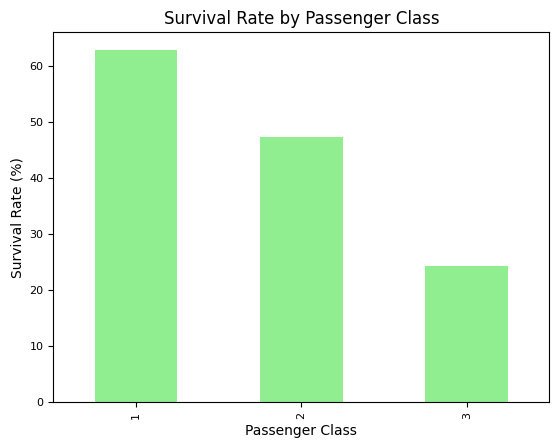

```python
survival_rate.plot(kind='bar', fontsize = 8, color='lightgreen')
plt.title ('Survival Rate by Passenger Class')
plt.xlabel('Passenger Class')
plt.ylabel('Survival Rate (%)')
plt.show()
```

survival_rate.plot , plot means we want to make charts. After that we type the title and lable for X and Y. the Y is durvival rate (%) and the X is passenger class.

Conclusion

We can summarize that the first class passengers have a high survival rate, compared to the second and third class passengers. We have more males passengers dan female. Reflect on this data, we know how socio economic of passenger has impact on their survival rate.